# Peer Assessment II

```r
load("ames_train.Rdata")
```

```r
library(statsr)
library(dplyr)
library(BAS)
```

```r
library(ggplot2)
```

## 0.1 Part 1 - Exploratory Data Analysis (EDA)

After you have explored completely, submit the three graphs/plots that you found most informative during your EDA process, and briefly explain what you learned from each (why you found each informative).

### 0.1.1 I found it very helpful to to look at the pricing of homes when grouping by neighborhood using a box and whisker plot. This allowed me to observe the level of variation, as well as the mean and quartiles within each neighborhood of the city.

### 0.1.2 This second box and whisker plot of price grouped by zoning was similarly as helpful as the the prior plot. I was able to see that low- and medium- depsity had much more variation in price relative to the other types of zoning.

### 0.1.3 Finally, for the 3rd helpful graph shows a scatter plot relationship between price and area of homes with a linear regression line the shows the positive association between these two variables. This graph also shows many large homes with relatively low pricing (under linear regression line) which might be homes worth looking at a little closer.

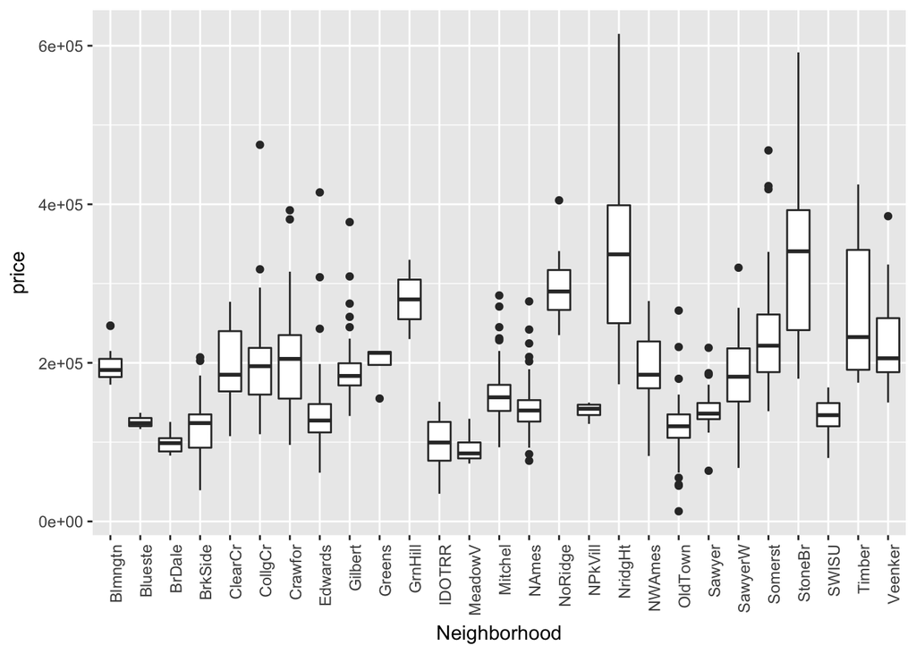

```r
ggplot(ames_train, aes(x = Neighborhood, y = price)) +
geom_boxplot() + theme(axis.text.x = element_text(angle = 90, hjust = 1))
```

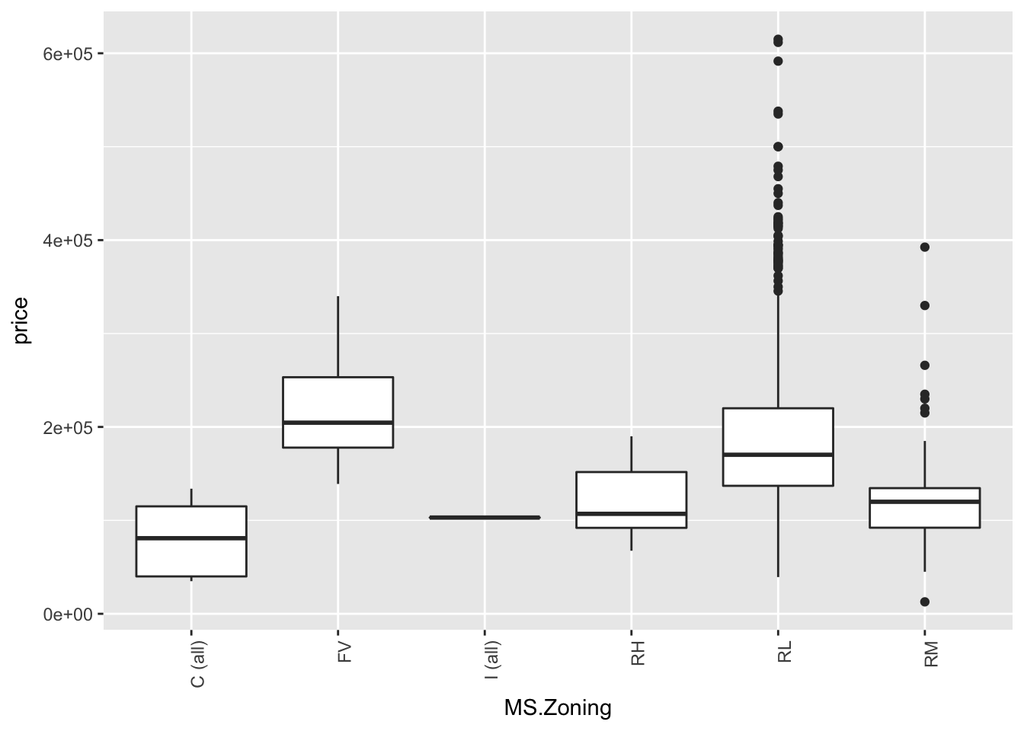

```r
# Price vs. Zoning
# Large Variation in RL and RM make them a prime target for undervalued property. The tight range of pricing in other zoning areas indicate potentially accurate pricing of property
ggplot(ames_train, aes(x = MS.Zoning, y = price)) +
geom_boxplot() + theme(axis.text.x = element_text(angle = 90, hjust = 1))
```

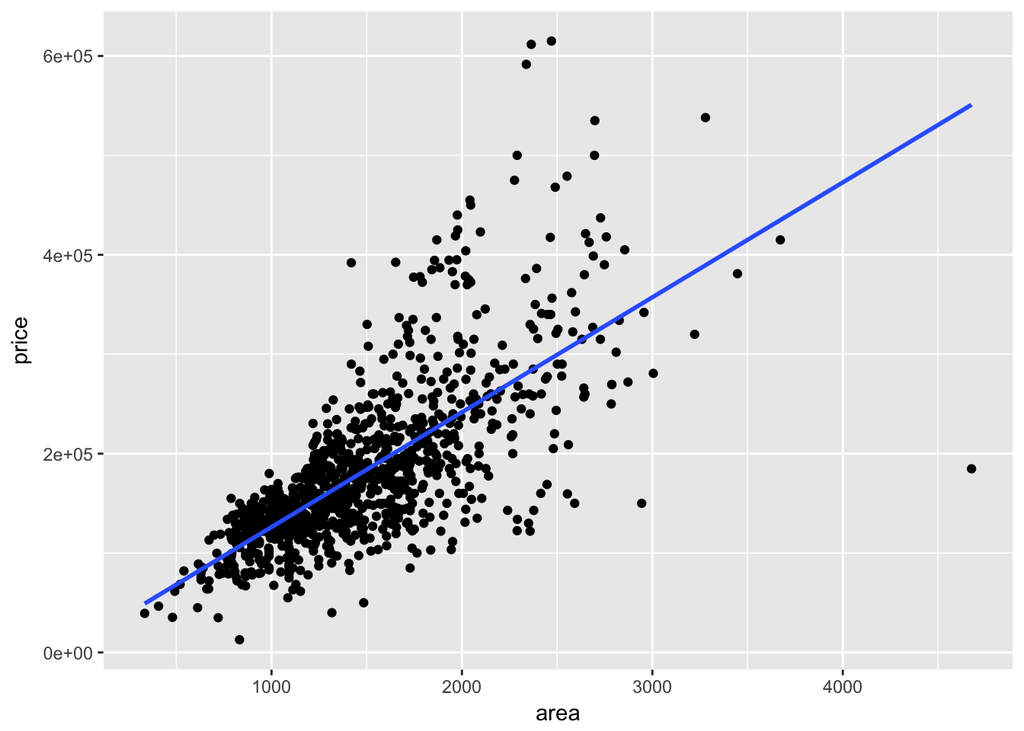

```r
ggplot(ames_train, aes(x = area, y = price)) + geom_point() + geom_smooth(method='lm', formula=y~x, se=FALSE)
```

## 0.2 Part 2 - Development and assessment of an initial model, following a semi-guided process of analysis

### 0.2.1 Section 2.1 An Initial Model

### 0.2.2 Using the ames_train data set there are many variables to chose from (81) and use a predictors in this model. Since I already know that area is positively associated with price I included is as a predictor in this model (also just using basic intution here). I also used my intutition to that zoning, year.built, overall.qual, year.remod.add, and lot.area were also likely key predictors in pricing. For neighborhood and land.slope I was more just curious to see if they are reasonable predictor variables.

### 0.2.3 We can see that area, Lot.Area, Year.Built, Overall.Qual, and Year.Remod.add are all significant predictors for price. Also, 8 certain neighborhoods are good at predicting price, as well as MS.ZoningRL and moderate or severe land slope.

```r
model2.1<-lm(price ~ area + Neighborhood + MS.Zoning + Lot.Area + Year.Built + Overall.Qual + Year.Remod.Add + Land.Slope, data=ames_train)
summary(model2.1)
```

```
##
## Call:
## lm(formula = price ~ area + Neighborhood + MS.Zoning + Lot.Area +
##     Year.Built + Overall.Qual + Year.Remod.Add + Land.Slope,
##     data = ames_train)
##
## Residuals:
##     Min      1Q  Median      3Q     Max
## -282203  -15918    -889   13812  242817
##
## Coefficients:
##                       Estimate Std. Error t value Pr(>|t|)
## (Intercept)         -1.783e+06  2.128e+05  -8.381  < 2e-16 ***
## area                 5.113e+01  3.087e+00  16.564  < 2e-16 ***
## NeighborhoodBlueste  1.605e+03  2.318e+04   0.069 0.944817
## NeighborhoodBrDale  -1.018e+04  1.642e+04  -0.620 0.535402
## NeighborhoodBrkSide  3.102e+04  1.398e+04   2.219 0.026742 *
## NeighborhoodClearCr  1.071e+04  1.528e+04   0.701 0.483508
## NeighborhoodCollgCr  3.319e+03  1.108e+04   0.300 0.764535
## NeighborhoodCrawfor  3.610e+04  1.329e+04   2.716 0.006722 **
## NeighborhoodEdwards  3.263e+03  1.200e+04   0.272 0.785771
## NeighborhoodGilbert -9.845e+03  1.158e+04  -0.850 0.395650
## NeighborhoodGreens   1.719e+04  2.030e+04   0.847 0.397339
## NeighborhoodGrnHill  1.044e+05  2.697e+04   3.871 0.000116 ***
## NeighborhoodIDOTRR   2.821e+04  1.531e+04   1.843 0.065655 .
## NeighborhoodMeadowV  5.787e+03  1.521e+04   0.380 0.703749
## NeighborhoodMitchel  7.352e+03  1.195e+04   0.615 0.538411
## NeighborhoodNAmes    1.416e+04  1.154e+04   1.227 0.220277
## NeighborhoodNoRidge  3.655e+04  1.251e+04   2.921 0.003567 **
## NeighborhoodNPkVill -9.629e+03  2.025e+04  -0.475 0.634592
## NeighborhoodNridgHt  7.147e+04  1.148e+04   6.226 7.13e-10 ***
## NeighborhoodNWAmes   7.231e+02  1.206e+04   0.060 0.952192
## NeighborhoodOldTown  2.421e+04  1.431e+04   1.692 0.091003 .
## NeighborhoodSawyer   1.143e+04  1.194e+04   0.957 0.338846
## NeighborhoodSawyerW -9.967e+03  1.172e+04  -0.850 0.395293
## NeighborhoodSomerst  4.833e+04  1.322e+04   3.656 0.000270 ***
## NeighborhoodStoneBr  7.726e+04  1.310e+04   5.900 5.04e-09 ***
## NeighborhoodSWISU    7.955e+03  1.585e+04   0.502 0.615926
## NeighborhoodTimber   3.199e+04  1.323e+04   2.419 0.015768 *
## NeighborhoodVeenker  1.725e+04  1.529e+04   1.128 0.259616
## MS.ZoningFV         -1.639e+04  1.683e+04  -0.974 0.330419
## MS.ZoningI (all)    -6.304e+04  3.690e+04  -1.708 0.087935 .
## MS.ZoningRH          2.836e+04  1.940e+04   1.462 0.144052
## MS.ZoningRL          2.764e+04  1.402e+04   1.972 0.048937 *
## MS.ZoningRM          1.174e+04  1.292e+04   0.908 0.363923
## Lot.Area             1.155e+00  1.503e-01   7.687 3.72e-14 ***
## Year.Built           5.978e+02  8.899e+01   6.717 3.17e-11 ***
## Overall.Qual         1.845e+04  1.410e+03  13.079  < 2e-16 ***
## Year.Remod.Add       2.738e+02  7.582e+01   3.610 0.000321 ***
## Land.SlopeMod        3.052e+04  6.403e+03   4.767 2.16e-06 ***
## Land.SlopeSev       -4.893e+04  1.980e+04  -2.471 0.013633 *
## ---
## Signif. codes:  0 '***' 0.001 '**' 0.01 '*' 0.05 '.' 0.1 ' ' 1
##
## Residual standard error: 34310 on 961 degrees of freedom
## Multiple R-squared:  0.8312, Adjusted R-squared:  0.8246
## F-statistic: 124.6 on 38 and 961 DF,  p-value: < 2.2e-16
```

### 0.2.4 Section 2.2 Model Selection

Now either using `BAS` or another stepwise selection procedure choose the “best” model you can, using your initial model as your starting point. Try at least two different model selection methods and compare their results. Do they both arrive at the same model or do they disagree? What do you think this means?

When using BAS selection, inclusion probabilities of area, certain neighborhoods, certain zoning, lot.area, year.built overall.qual, yera.remod, land.slope are all relatively high (close or equal to 1.0). When using stepwise backward elimination, area, certain neighborhoods, certain zoning, lot.area, year.built, overall.qual, year.remod.add, and land.slope all have p-values less than 0.05. This means that both of the models agree with each other. I think this means they are both effective methods for model selection.

```r
# BAS
model2.2.1<-bas.lm(price ~ area + Neighborhood + MS.Zoning + Lot.Area + Year.Built + Overall.Qual + Year.Remod.Add + Land.Slope, data=ames_train)
model2.2.1
```

```
##
## Call:
## bas.lm(formula = price ~ area + Neighborhood + MS.Zoning + Lot.Area +     Year.Built + Overall.Qual + Year.Remod.Add + Land.Slope,     data = ames_train)
##
##
##  Marginal Posterior Inclusion Probabilities:
##           Intercept                 area  NeighborhoodBlueste
##             1.00000              1.00000              0.04850
##  NeighborhoodBrDale  NeighborhoodBrkSide  NeighborhoodClearCr
##             0.46704              0.34259              0.04094
## NeighborhoodCollgCr  NeighborhoodCrawfor  NeighborhoodEdwards
##             0.05413              0.95928              0.11406
## NeighborhoodGilbert   NeighborhoodGreens  NeighborhoodGrnHill
##             0.39348              0.04663              0.98694
##  NeighborhoodIDOTRR  NeighborhoodMeadowV  NeighborhoodMitchel
##             0.05138              0.09443              0.04274
##   NeighborhoodNAmes  NeighborhoodNoRidge  NeighborhoodNPkVill
##             0.28203              0.99980              0.06453
## NeighborhoodNridgHt   NeighborhoodNWAmes  NeighborhoodOldTown
##             1.00000              0.06859              0.06065
##  NeighborhoodSawyer  NeighborhoodSawyerW  NeighborhoodSomerst
##             0.05945              0.47408              0.99997
## NeighborhoodStoneBr    NeighborhoodSWISU   NeighborhoodTimber
##             1.00000              0.05077              0.97424
## NeighborhoodVeenker          MS.ZoningFV     MS.ZoningI (all)
##             0.09679              0.93693              0.28804
##         MS.ZoningRH          MS.ZoningRL          MS.ZoningRM
##             0.04746              0.66307              0.21016
##            Lot.Area           Year.Built         Overall.Qual
##             1.00000              1.00000              1.00000
##      Year.Remod.Add        Land.SlopeMod        Land.SlopeSev
##             0.96905              0.99998              0.46988
```

```r
# Backwards Step Wise
model2.2.2<-step(lm(price ~ area + Neighborhood + MS.Zoning + Lot.Area + Year.Built + Overall.Qual + Year.Remod.Add + Land.Slope, data=ames_train),direction='backward')
```

```
## Start:  AIC=20924.43
## price ~ area + Neighborhood + MS.Zoning + Lot.Area + Year.Built +
##     Overall.Qual + Year.Remod.Add + Land.Slope
##
##                  Df  Sum of Sq        RSS   AIC
## <none>                         1.1311e+12 20924
## - Year.Remod.Add  1 1.5342e+10 1.1464e+12 20936
## - MS.Zoning       5 4.1785e+10 1.1729e+12 20951
## - Land.Slope      2 3.7471e+10 1.1685e+12 20953
## - Year.Built      1 5.3105e+10 1.1842e+12 20968
## - Lot.Area        1 6.9542e+10 1.2006e+12 20982
## - Overall.Qual    1 2.0135e+11 1.3324e+12 21086
## - Neighborhood   26 3.5734e+11 1.4884e+12 21147
## - area            1 3.2292e+11 1.4540e+12 21174
```

```r
summary(model2.2.2)
```

```
##
## Call:
## lm(formula = price ~ area + Neighborhood + MS.Zoning + Lot.Area +
##     Year.Built + Overall.Qual + Year.Remod.Add + Land.Slope,
##     data = ames_train)
##
## Residuals:
##     Min      1Q  Median      3Q     Max
## -282203  -15918    -889   13812  242817
##
## Coefficients:
##                       Estimate Std. Error t value Pr(>|t|)
## (Intercept)         -1.783e+06  2.128e+05  -8.381  < 2e-16 ***
## area                 5.113e+01  3.087e+00  16.564  < 2e-16 ***
## NeighborhoodBlueste  1.605e+03  2.318e+04   0.069 0.944817
## NeighborhoodBrDale  -1.018e+04  1.642e+04  -0.620 0.535402
## NeighborhoodBrkSide  3.102e+04  1.398e+04   2.219 0.026742 *
## NeighborhoodClearCr  1.071e+04  1.528e+04   0.701 0.483508
## NeighborhoodCollgCr  3.319e+03  1.108e+04   0.300 0.764535
## NeighborhoodCrawfor  3.610e+04  1.329e+04   2.716 0.006722 **
## NeighborhoodEdwards  3.263e+03  1.200e+04   0.272 0.785771
## NeighborhoodGilbert -9.845e+03  1.158e+04  -0.850 0.395650
## NeighborhoodGreens   1.719e+04  2.030e+04   0.847 0.397339
## NeighborhoodGrnHill  1.044e+05  2.697e+04   3.871 0.000116 ***
## NeighborhoodIDOTRR   2.821e+04  1.531e+04   1.843 0.065655 .
## NeighborhoodMeadowV  5.787e+03  1.521e+04   0.380 0.703749
## NeighborhoodMitchel  7.352e+03  1.195e+04   0.615 0.538411
## NeighborhoodNAmes    1.416e+04  1.154e+04   1.227 0.220277
## NeighborhoodNoRidge  3.655e+04  1.251e+04   2.921 0.003567 **
## NeighborhoodNPkVill -9.629e+03  2.025e+04  -0.475 0.634592
## NeighborhoodNridgHt  7.147e+04  1.148e+04   6.226 7.13e-10 ***
## NeighborhoodNWAmes   7.231e+02  1.206e+04   0.060 0.952192
## NeighborhoodOldTown  2.421e+04  1.431e+04   1.692 0.091003 .
## NeighborhoodSawyer   1.143e+04  1.194e+04   0.957 0.338846
## NeighborhoodSawyerW -9.967e+03  1.172e+04  -0.850 0.395293
## NeighborhoodSomerst  4.833e+04  1.322e+04   3.656 0.000270 ***
## NeighborhoodStoneBr  7.726e+04  1.310e+04   5.900 5.04e-09 ***
## NeighborhoodSWISU    7.955e+03  1.585e+04   0.502 0.615926
## NeighborhoodTimber   3.199e+04  1.323e+04   2.419 0.015768 *
## NeighborhoodVeenker  1.725e+04  1.529e+04   1.128 0.259616
## MS.ZoningFV         -1.639e+04  1.683e+04  -0.974 0.330419
## MS.ZoningI (all)    -6.304e+04  3.690e+04  -1.708 0.087935 .
## MS.ZoningRH          2.836e+04  1.940e+04   1.462 0.144052
## MS.ZoningRL          2.764e+04  1.402e+04   1.972 0.048937 *
## MS.ZoningRM          1.174e+04  1.292e+04   0.908 0.363923
## Lot.Area             1.155e+00  1.503e-01   7.687 3.72e-14 ***
## Year.Built           5.978e+02  8.899e+01   6.717 3.17e-11 ***
## Overall.Qual         1.845e+04  1.410e+03  13.079  < 2e-16 ***
## Year.Remod.Add       2.738e+02  7.582e+01   3.610 0.000321 ***
## Land.SlopeMod        3.052e+04  6.403e+03   4.767 2.16e-06 ***
## Land.SlopeSev       -4.893e+04  1.980e+04  -2.471 0.013633 *
## ---
## Signif. codes:  0 '***' 0.001 '**' 0.01 '*' 0.05 '.' 0.1 ' ' 1
##
## Residual standard error: 34310 on 961 degrees of freedom
## Multiple R-squared:  0.8312, Adjusted R-squared:  0.8246
## F-statistic: 124.6 on 38 and 961 DF,  p-value: < 2.2e-16
```

### 0.2.5 Section 2.3 Initial Model Residuals

One way to assess the performance of a model is to examine the model’s residuals. In the space below, create a residual plot for your preferred model from above and use it to assess whether your model appears to fit the data well. Comment on any interesting structure in the residual plot (trend, outliers, etc.) and briefly discuss potential implications it may have for your model and inference / prediction you might produce.

### 0.2.6 There’s a propensity to underpredict for higher fitted values (greater than $250,000). The model also appears to be generally well-fitted for homes under $250,000. There is one extreme outlier and a handful more that could be argued to outliers.

### 0.2.7 If there’s a propensity to underpredict for higher fitted values, the model should be used with great caution if the firm is looking to purchase these higher-valued homes.

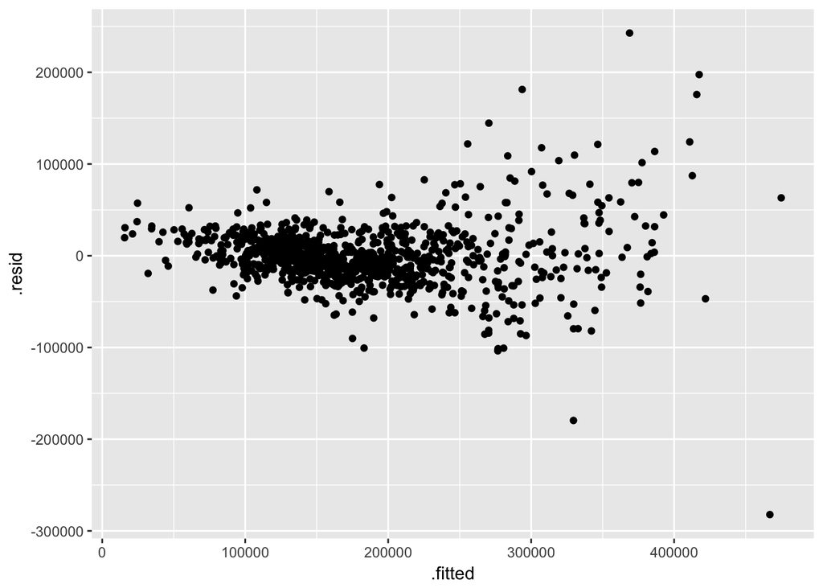

```r
residuals2.2.2<-resid(model2.2.2)
df2.2.2<-fortify(model2.2.2)
options(scipen = 999)
ggplot(df2.2.2, aes(x = .fitted, y = .resid)) + geom_point()
```

### 0.2.8 Section 2.4 Initial Model RMSE

You can calculate it directly based on the model output. Be specific about the units of your RMSE (depending on whether you transformed your response variable).

### 0.2.9 RMSE = $33631.43

```r
rmse2.2.2<-sqrt(mean(residuals2.2.2^2))
rmse2.2.2
```

```
## [1] 33631.43
```

### 0.2.10 Section 2.5 Overfitting

```r
load("ames_test.Rdata")
```

Are the predictions significantly more accurate (compared to the actual sales prices) for the training data than the test data? Why or why not? Briefly explain how you determined that (what steps or processes did you use)?

### 0.2.11 The model is not exhibiting overfitting as evidence by the decline in RMSE ($31696.81).

### 0.2.12 The residual plot also ehibits a similar distribuation to the training data set and a greater discrepency in the preddiction for properties above $250,000.

### 0.2.13 The out of sample data set displayed an inability for the model to process unforeseen data (Neighborhood=Landmrk).

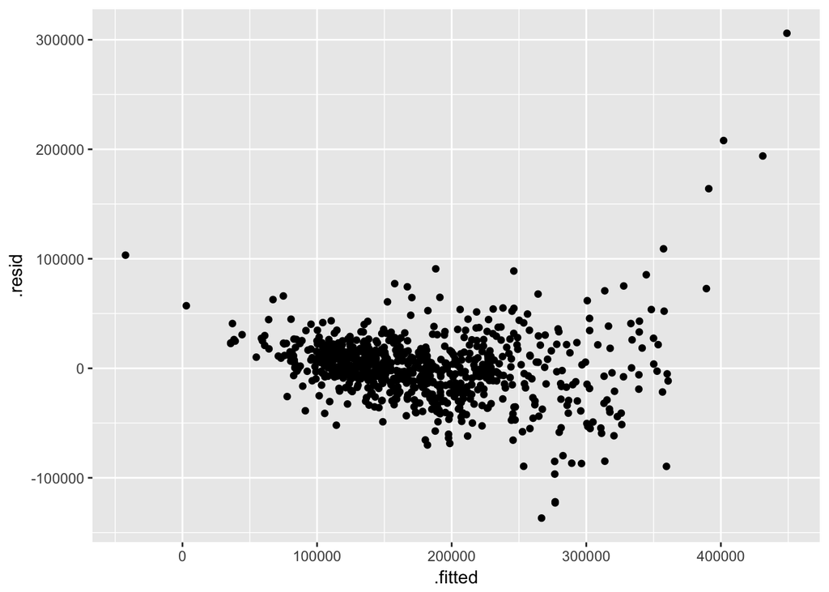

```r
# New Neighborhoods in test data require fixing for predictions
id<-ames_test$Neighborhood %in% 'Landmrk'
ames_test$Neighborhood[id]<-NA
# Generate Predictions and Error Metrics
predictions2.5<-predict(model2.2.2,ames_test)
residuals2.5<-ames_test$price-predictions2.5
df2.5<-data.frame(.fitted=predictions2.5,.resid=residuals2.5)
df2.5<-na.omit(df2.5)
ggplot(df2.5, aes(x = .fitted, y = .resid)) + geom_point()
```

```r
rmse2.5<-sqrt(mean(df2.5$.resid^2))
rmse2.5
```

```
## [1] 31696.81
```

## 0.3 Part 3 Development of a Final Model

Now that you have developed an initial model to use as a baseline, create a final model with *at most* 20 variables to predict housing prices in Ames, IA, selecting from the full array of variables in the dataset and using any of the tools that we introduced in this specialization.

### 0.3.1 Section 3.1 Final Model

```r
# Backwards Step Wise
model3.1<-step(lm(log(price)~area + Lot.Area +Street + Lot.Shape + Land.Contour +Lot.Config +Land.Slope + Bldg.Type +Overall.Qual +Overall.Cond +Year.Built + Year.Remod.Add  +Exter.Qual+Full.Bath  +Half.Bath +Bedroom.AbvGr +Kitchen.AbvGr +TotRms.AbvGrd +Functional +Fireplaces +Sale.Condition,ames_train),direction='backward')
```

```
## Start:  AIC=-3639.51
## log(price) ~ area + Lot.Area + Street + Lot.Shape + Land.Contour +
##     Lot.Config + Land.Slope + Bldg.Type + Overall.Qual + Overall.Cond +
##     Year.Built + Year.Remod.Add + Exter.Qual + Full.Bath + Half.Bath +
##     Bedroom.AbvGr + Kitchen.AbvGr + TotRms.AbvGrd + Functional +
##     Fireplaces + Sale.Condition
##
##                  Df Sum of Sq    RSS     AIC
## - Functional      6    0.1408 24.193 -3645.7
## - Lot.Config      4    0.0759 24.128 -3644.4
## - Lot.Shape       3    0.0366 24.089 -3644.0
## - Land.Contour    3    0.0432 24.096 -3643.7
## - TotRms.AbvGrd   1    0.0088 24.061 -3641.1
## - Street          1    0.0173 24.070 -3640.8
## - Kitchen.AbvGr   1    0.0195 24.072 -3640.7
## <none>                        24.053 -3639.5
## - Land.Slope      2    0.1088 24.161 -3639.0
## - Year.Remod.Add  1    0.0998 24.152 -3637.4
## - Exter.Qual      3    0.2327 24.285 -3635.9
## - Bedroom.AbvGr   1    0.1574 24.210 -3635.0
## - Full.Bath       1    0.2031 24.256 -3633.1
## - Lot.Area        1    0.4327 24.485 -3623.7
## - Half.Bath       1    0.4629 24.515 -3622.5
## - Sale.Condition  5    0.7310 24.784 -3619.6
## - Fireplaces      1    0.7196 24.772 -3612.0
## - Bldg.Type       4    1.1180 25.171 -3602.1
## - Overall.Cond    1    2.2335 26.286 -3552.7
## - area            1    4.5364 28.589 -3468.7
## - Overall.Qual    1    4.8052 28.858 -3459.4
## - Year.Built      1    6.0249 30.078 -3418.0
##
## Step:  AIC=-3645.68
## log(price) ~ area + Lot.Area + Street + Lot.Shape + Land.Contour +
##     Lot.Config + Land.Slope + Bldg.Type + Overall.Qual + Overall.Cond +
##     Year.Built + Year.Remod.Add + Exter.Qual + Full.Bath + Half.Bath +
##     Bedroom.AbvGr + Kitchen.AbvGr + TotRms.AbvGrd + Fireplaces +
##     Sale.Condition
##
##                  Df Sum of Sq    RSS     AIC
## - Lot.Config      4    0.0670 24.260 -3650.9
```

[output cut: 157 more lines]

```
## <none>                        24.412 -3662.7
## - Land.Slope      2    0.1326 24.545 -3661.3
## - Year.Remod.Add  1    0.1067 24.519 -3660.3
## - Bedroom.AbvGr   1    0.1557 24.568 -3658.3
## - Exter.Qual      3    0.3247 24.737 -3655.5
## - Full.Bath       1    0.2400 24.652 -3654.9
## - Half.Bath       1    0.4613 24.874 -3645.9
## - Sale.Condition  5    0.7296 25.142 -3643.2
## - Lot.Area        1    0.6333 25.046 -3639.1
## - Fireplaces      1    0.7931 25.205 -3632.7
## - Bldg.Type       4    1.4136 25.826 -3614.4
## - Overall.Cond    1    2.5627 26.975 -3564.8
## - Overall.Qual    1    5.4470 29.859 -3463.3
## - area            1    6.3499 30.762 -3433.5
## - Year.Built      1    7.1590 31.571 -3407.5
```

```r
summary(model3.1)
```

```
##
## Call:
## lm(formula = log(price) ~ area + Lot.Area + Land.Slope + Bldg.Type +
##     Overall.Qual + Overall.Cond + Year.Built + Year.Remod.Add +
##     Exter.Qual + Full.Bath + Half.Bath + Bedroom.AbvGr + Fireplaces +
##     Sale.Condition, data = ames_train)
##
## Residuals:
##      Min       1Q   Median       3Q      Max
## -1.68916 -0.07804  0.00393  0.08987  0.48275
##
## Coefficients:
##                            Estimate    Std. Error t value
## (Intercept)           -0.6643043412  0.7502572484  -0.885
## area                   0.0003411094  0.0000214197  15.925
## Lot.Area               0.0000033754  0.0000006711   5.029
## Land.SlopeMod          0.0629436901  0.0291686410   2.158
## Land.SlopeSev         -0.0553927387  0.0878293683  -0.631
## Bldg.Type2fmCon        0.0473471933  0.0374535809   1.264
## Bldg.TypeDuplex       -0.0558293448  0.0306455111  -1.822
## Bldg.TypeTwnhs        -0.1892363195  0.0277589117  -6.817
## Bldg.TypeTwnhsE       -0.0691866764  0.0205443787  -3.368
## Overall.Qual           0.0976041527  0.0066174430  14.750
## Overall.Cond           0.0573937445  0.0056730168  10.117
## Year.Built             0.0049818257  0.0002946219  16.909
## Year.Remod.Add         0.0007816687  0.0003786422   2.064
## Exter.QualFa          -0.1980623088  0.0624900620  -3.170
## Exter.QualGd          -0.0882811365  0.0301734515  -2.926
## Exter.QualTA          -0.1142255747  0.0353923864  -3.227
## Full.Bath             -0.0462895981  0.0149523378  -3.096
## Half.Bath             -0.0544503262  0.0126853566  -4.292
## Bedroom.AbvGr         -0.0218326554  0.0087554240  -2.494
## Fireplaces             0.0531472962  0.0094431944   5.628
## Sale.ConditionAdjLand  0.1308515848  0.1173981831   1.115
## Sale.ConditionAlloca   0.1848243703  0.0828461773   2.231
## Sale.ConditionFamily  -0.0026871526  0.0439954095  -0.061
## Sale.ConditionNormal   0.0939797873  0.0213307003   4.406
## Sale.ConditionPartial  0.1244065254  0.0290168884   4.287
##                                   Pr(>|t|)
## (Intercept)                       0.376140
```

[output cut: 15 more lines]

```
## Full.Bath                         0.002019 **
## Half.Bath                  0.0000194415527 ***
## Bedroom.AbvGr                     0.012810 *
## Fireplaces                 0.0000000238105 ***
## Sale.ConditionAdjLand             0.265298
## Sale.ConditionAlloca              0.025912 *
## Sale.ConditionFamily              0.951310
## Sale.ConditionNormal       0.0000117040907 ***
## Sale.ConditionPartial      0.0000198752777 ***
## ---
## Signif. codes:  0 '***' 0.001 '**' 0.01 '*' 0.05 '.' 0.1 ' ' 1
##
## Residual standard error: 0.1582 on 975 degrees of freedom
## Multiple R-squared:  0.8619, Adjusted R-squared:  0.8585
## F-statistic: 253.5 on 24 and 975 DF,  p-value: < 0.00000000000000022
```

### 0.3.2 Section 3.2 Transformation

Did you decide to transform any variables? Why or why not? Explain in a few sentences.

### 0.3.3 Log-transformed price: The residual plots have random noise centered around 0, yet there is a departure from the centrality at the extremity of estimatated prices. To correct this, its appropriate to perfrom a log-transformation of the dependent variable (price).

### 0.3.4 Section 3.3 Variable Interaction

Did you decide to include any variable interactions? Why or why not? Explain in a few sentences.

### 0.3.5 No, I decided to not include any variable interactions because none of the variables appeared to have a link that provides additional information beyond the single variables.

### 0.3.6 Section 3.4 Variable Selection

What method did you use to select the variables you included? Why did you select the method you used? Explain in a few sentences.

### 0.3.7 Initial pruning of all variables based off of EDA and codebook datatype summaries.

### 0.3.8 Backwards stepwise regression determined variables for the final model.

### 0.3.9 Backwards stepwise is an efficient and tranparent method for determining variable selection.

### 0.3.10 Section 3.5 Model Testing

How did testing the model on out-of-sample data affect whether or how you changed your model? Explain in a few sentences.

### 0.3.11 Given insufficient data in some categorical variables (e.g. Neighborhood-Landmrk) to generate predictions for all properties, certain variables were excluded from the final model stepwise selection process.

## 0.4 Part 4 Final Model Assessment

### 0.4.1 Section 4.1 Final Model Residual

For your final model, create and briefly interpret an informative plot of the residuals.

### 0.4.2 In large, the model error has reduced and the discrepency for high valued properties (above $250,000) has declined, however there was one extreme outlier that I removed in the second residul graph.

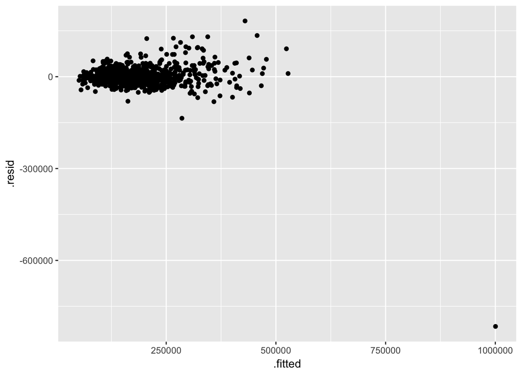

```r
predictions4.1<-exp(predict(model3.1,ames_train))
residuals4.1<-ames_train$price-predictions4.1
df4.1<-data.frame(.fitted=predictions4.1,.resid=residuals4.1)
ggplot(df4.1, aes(x = .fitted, y = .resid)) + geom_point() # Add Labels
```

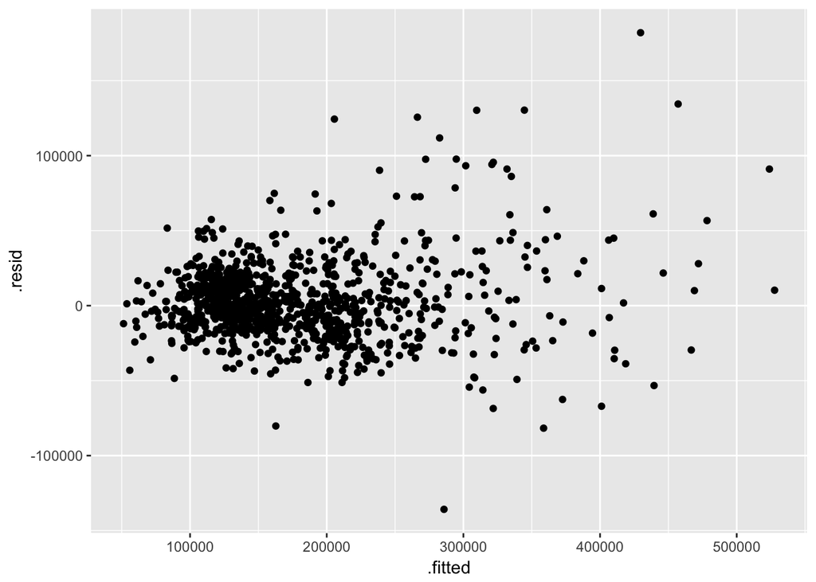

```r
# Residuals with out extreme outlier
residuals4.1nooutlier<-residuals4.1[residuals4.1>min(residuals4.1)]
predictions4.1nooutlier<-predictions4.1[predictions4.1<max(predictions4.1)]
df4.1nooutlier<-data.frame(.fitted=predictions4.1nooutlier,.resid=residuals4.1nooutlier)
ggplot(df4.1nooutlier, aes(x = .fitted, y = .resid)) + geom_point() # Add Labels
```

### 0.4.3 Section 4.2 Final Model RMSE

For your final model, calculate and briefly comment on the RMSE.

### 0.4.4 RMSE with all esimates included is higher ($37024.54) than the initial model, but with the removal of the extreme outlier, the RMSE is lower ($26574.9) than the initial model.

```r
# RMSE with all predictions
rmse4.2<-sqrt(mean(residuals4.1^2))
rmse4.2
```

```
## [1] 37024.54
```

```r
# RMSE single outlier removed
rmse4.2nooutlier<-sqrt(mean(residuals4.1nooutlier^2))
rmse4.2nooutlier
```

```
## [1] 26574.9
```

```r
# In Dollars
```

### 0.4.5 Section 4.3 Final Model Evaluation

What are some strengths and weaknesses of your model?

### 0.4.6 Strengths: More rubust than first model, the mean is not biased to over- or underestimate, the errors largerly appear to be random, includes a variety of numerical and categorical variables that describe the property.

### 0.4.7 Weaknesses: Masive error associated with one specific outlier likely due to input error, model has inability to predict with new categorical variables that were not in the training set, model accuracy declines for properties beyond $250,000.

### 0.4.8 Section 4.4 Final Model Validation

Testing your final model on a separate, validation data set is a great way to determine how your model will perform in real-life practice.

You will use the “ames_validation” dataset to do some additional assessment of your final model. Discuss your findings, be sure to mention: * What is the RMSE of your final model when applied to the validation data?  
* How does this value compare to that of the training data and/or testing data? * What percentage of the 95% predictive confidence (or credible) intervals contain the true price of the house in the validation data set?  
* From this result, does your final model properly reflect uncertainty?

```r
load("ames_validation.Rdata")
```

### 0.4.9 Final RMSE for final model is $22268.67.

### 0.4.10 RMSE for validation data is smaller than RMSE for training data.

### 0.4.11 98.2% of property prices are in the 95% CI. The slight upward increase from 95 to 98 is likely due to the reduction of RMSE from training to validation.

### 0.4.12 The model accurately reflects the uncertainty of property pricing.

```r
# Predict
predictions4.4<-predict(model3.1,ames_validation)
# RMSE
residuals4.4<-ames_validation$price-exp(predictions4.4)
rmse4.4<-sqrt(mean(residuals4.4^2))
rmse4.4
```

```
## [1] 22268.67
```

```r
# What percentage of 95% CI contains the true price
intervals4.4<-predict(model3.1,ames_validation,interval='predict')
intervals4.4<-exp(intervals4.4)
intervals4.4<-data.frame(intervals4.4)
sum(intervals4.4$upr>=ames_validation$price & ames_validation$price>=intervals4.4$lwr)/nrow(ames_validation)
```

```
## [1] 0.9816514
```

## 0.5 Part 5 Conclusion

Provide a brief summary of your results, and a brief discussion of what you have learned about the data and your model.

### 0.5.1 I learned that the model is more rubust than the first model, yet the model has an inability to predict with new categorical variables that were not in the training set, anbd its accuracy declines for properties beyond $250,000. Also the error for validation is smaller than training, which proves the models utility. The model was capable of making accurate predictions on unseen data as evidence by a decline in model error. The model appears to accurately represent the esimated uncertainty of it predictions. The uncertainty around the price can sometimes be large enough that investors should understand that there is still some risk in property investment when using the model to make purchasing decisions.